# Python_Final_Project_V2

### VI. Prediction model

```python
df.describe()
```

|  | Gender | Age | Height | Weight | Family_history_with_overweight | Frequency_eat_high_caloric_food | Frequency_eat_vegetables | Number_of_main_meals | Frequency_eat_between_meals | Smoke | ... | Time_using_technology_devices | Frequency_alcohol | Obesity_level_category | Main_transport_Automobile | Main_transport_Bike | Main_transport_Motorbike | Main_transport_Public_Transportation | Main_transport_Walking | MBI | Corrected_obesity_level_category |
| --- | --- | --- | --- | --- | --- | --- | --- | --- | --- | --- | --- | --- | --- | --- | --- | --- | --- | --- | --- | --- | --- |
| count | 2087.000000 | 2087.000000 | 2087.000000 | 2087.000000 | 2087.000000 | 2087.000000 | 2087.000000 | 2087.000000 | 2087.000000 | 2087.000000 | ... | 2087.000000 | 2087.000000 | 2087.000000 | 2087.000000 | 2087.000000 | 2087.000000 | 2087.000000 | 2087.000000 | 2087.000000 | 2087.000000 |
| mean | 0.504073 | 24.009104 | 1.702616 | 86.858649 | 0.825108 | 0.883565 | 2.421466 | 2.701179 | 1.853857 | 0.021083 | ... | 0.663035 | 2.270244 | 3.014375 | 0.218495 | 0.003354 | 0.005271 | 0.746526 | 0.026354 | 29.768852 | 2.484907 |
| std | 0.500103 | 6.333297 | 0.093251 | 26.190841 | 0.379966 | 0.320823 | 0.534737 | 0.764614 | 0.459494 | 0.143695 | ... | 0.608153 | 0.517008 | 1.948470 | 0.413324 | 0.057831 | 0.072426 | 0.435104 | 0.160223 | 8.029520 | 1.543128 |
| min | 0.000000 | 14.000000 | 1.450000 | 39.000000 | 0.000000 | 0.000000 | 1.000000 | 1.000000 | 0.000000 | 0.000000 | ... | 0.000000 | 0.000000 | 0.000000 | 0.000000 | 0.000000 | 0.000000 | 0.000000 | 0.000000 | 12.989340 | 0.000000 |
| 25% | 0.000000 | 19.000000 | 1.630000 | 66.000000 | 1.000000 | 1.000000 | 2.000000 | 2.697467 | 2.000000 | 0.000000 | ... | 0.000000 | 2.000000 | 1.000000 | 0.000000 | 0.000000 | 0.000000 | 0.000000 | 0.000000 | 24.368897 | 1.000000 |
| 50% | 1.000000 | 22.000000 | 1.700000 | 83.100000 | 1.000000 | 1.000000 | 2.396265 | 3.000000 | 2.000000 | 0.000000 | ... | 0.630866 | 2.000000 | 3.000000 | 0.000000 | 0.000000 | 0.000000 | 1.000000 | 0.000000 | 28.864427 | 2.000000 |
| 75% | 1.000000 | 26.000000 | 1.770000 | 108.000000 | 1.000000 | 1.000000 | 3.000000 | 3.000000 | 2.000000 | 0.000000 | ... | 1.000000 | 3.000000 | 5.000000 | 0.000000 | 0.000000 | 0.000000 | 1.000000 | 0.000000 | 36.068560 | 4.000000 |
| max | 1.000000 | 61.000000 | 1.980000 | 173.000000 | 1.000000 | 1.000000 | 3.000000 | 4.000000 | 3.000000 | 1.000000 | ... | 2.000000 | 3.000000 | 6.000000 | 1.000000 | 1.000000 | 1.000000 | 1.000000 | 1.000000 | 50.820275 | 5.000000 |

8 rows × 23 columns

```python
sorted_corr = corr['Corrected_obesity_level_category'].abs().sort_values()
print(sorted_corr)
```

```
Smoke                                   0.005760
Main_transport_Bike                     0.028977
Number_of_main_meals                    0.029756
Main_transport_Motorbike                0.035747
Main_transport_Automobile               0.040675
Gender                                  0.052256
Main_transport_Public_Transportation    0.095328
Height                                  0.121205
Time_using_technology_devices           0.123959
Main_transport_Walking                  0.127328
Frequency_water                         0.142130
Frequency_alcohol                       0.180556
Monitoring_calories_consumption         0.183180
Frequency_physical_activity             0.188024
Age                                     0.237302
Frequency_eat_vegetables                0.249608
Frequency_eat_high_caloric_food         0.257411
Frequency_eat_between_meals             0.333918
Obesity_level_category                  0.428480
Family_history_with_overweight          0.482375
Weight                                  0.916672
MBI                                     0.982481
Corrected_obesity_level_category        1.000000
Name: Corrected_obesity_level_category, dtype: float64
```

Based on the correlation heatmap we've done before, we can directly see which variable have a bigger correlation with our "corrected_obesity_level_category".

However we will follow what we've seen in our previous analysis and drop some columns based on the work done in part III.

Since we want to predict the obesity type and we have access to this through the column "corrected_obesity_level_category", we're gonna do some supervised learning.

Let's make a quick pipeline to quickly see different algorithms first.

```python
Y = df['Corrected_obesity_level_category']
X = df.drop(columns = ['Corrected_obesity_level_category', 'MBI', 'Obesity_level_category', 'Weight','Number_of_main_meals', 'Main_transport_Bike', 'Main_transport_Automobile', 'Main_transport_Motorbike','Main_transport_Public_Transportation','Main_transport_Walking', 'Smoke'])
```

```python
x_train, x_test, y_train, y_test = train_test_split(X,Y,test_size=0.2,random_state=1, stratify = Y)
```

First we split the dataset into training and testing, and X (our variables) and Y (what we want to predict)

```python
ss = StandardScaler()
x_train_scaled = ss.fit_transform(x_train)
x_test_scaled = ss.transform(x_test)

mm = MinMaxScaler()
x_train_mm_scaled = ss.fit_transform(x_train)
x_test_mm_scaled = ss.transform(x_test)
```

```python
pipeline = [
    ('Random Forest', RandomForestClassifier()),
    ('Decision Tree', DecisionTreeClassifier()),
    ('KNN', KNeighborsClassifier()),
    ('SVM', SVC())
]
```

We're testing for 4 different classification algorithms.

```python
def model_predict(X_train: pd.DataFrame, y_train: pd.DataFrame,X_test: pd.DataFrame, y_test: pd.DataFrame):
  for name, model in pipeline:

          clf = model.fit(x_train, y_train)
          y_pred = clf.predict(x_test)

          clf_scaled = model.fit(x_train_scaled, y_train)
          y_pred_ss_scaled = clf_scaled.predict(x_test_scaled)

          clf_mm_scaled = model.fit(x_train_scaled, y_train)
          y_pred_mm_scaled = clf_scaled.predict(x_test_scaled)

          accuracy = round(accuracy_score(y_test, y_pred),5)
          scaled_ss_accuracy = round(accuracy_score(y_test, y_pred_ss_scaled),5)
          scaled_mm_accuracy = round(accuracy_score(y_test, y_pred_mm_scaled),5)


          print(name + ':')
          print("---------------------------------------------------------------")
          print("Accuracy:", accuracy)
          print("Accuracy w/Scaled_ss_accuracy Data (ss):", scaled_ss_accuracy)
          print("Accuracy w/scaled_mm_accuracy Data (mm):", scaled_mm_accuracy)
          if (accuracy > scaled_ss_accuracy) and (accuracy > scaled_mm_accuracy):
              print("\nClassification Report:\n", classification_report(y_test, y_pred))
              print("                            -----------------------------------               \n")
          elif (scaled_ss_accuracy > scaled_mm_accuracy):
              print("\nClassification Report (ss):\n", classification_report(y_test, y_pred_ss_scaled))
              print("                            -----------------------------------               \n")
          else:
              print("\nClassification Report (mm):\n", classification_report(y_test, y_pred_mm_scaled))
              print("                            -----------------------------------               \n")
```

```python
model_predict(x_train,y_train,x_test,y_test)
```

```
Random Forest:
---------------------------------------------------------------
Accuracy: 0.84211
Accuracy w/Scaled_ss_accuracy Data (ss): 0.8445
Accuracy w/scaled_mm_accuracy Data (mm): 0.84689

Classification Report (mm):
               precision    recall  f1-score   support

           0       0.94      0.87      0.90        53
           1       0.64      0.64      0.64        59
           2       0.82      0.85      0.84       111
           3       0.89      0.85      0.87        74
           4       0.87      0.90      0.88        68
           5       0.95      0.98      0.96        53

    accuracy                           0.85       418
   macro avg       0.85      0.85      0.85       418
weighted avg       0.85      0.85      0.85       418

                            -----------------------------------

Decision Tree:
---------------------------------------------------------------
Accuracy: 0.69139
Accuracy w/Scaled_ss_accuracy Data (ss): 0.69617
Accuracy w/scaled_mm_accuracy Data (mm): 0.69378

Classification Report (ss):
               precision    recall  f1-score   support

           0       0.69      0.77      0.73        53
           1       0.46      0.37      0.41        59
           2       0.71      0.62      0.66       111
           3       0.65      0.78      0.71        74
           4       0.74      0.75      0.74        68
           5       0.89      0.94      0.92        53

    accuracy                           0.70       418
   macro avg       0.69      0.71      0.70       418
```

[output cut: 32 more lines]

```
Classification Report (mm):
               precision    recall  f1-score   support

           0       0.75      0.68      0.71        53
           1       0.60      0.53      0.56        59
           2       0.72      0.69      0.71       111
           3       0.71      0.61      0.66        74
           4       0.71      0.91      0.80        68
           5       0.82      0.94      0.88        53

    accuracy                           0.72       418
   macro avg       0.72      0.73      0.72       418
weighted avg       0.72      0.72      0.71       418

                            -----------------------------------
```

So as we can see, the random tree classifier seems to be the more accurate. Let's give it a closer look.

We can use a random forest classifier. It's basically creating lots of decision trees, and then use them all to decide. It's really effective for classification problems such as this one. Each decision trees will take into account a fixed amount of variable among every variables, to create more variation among the trees.

```python
x_train, x_test, y_train, y_test = train_test_split(X,Y,test_size=0.2,random_state=2, stratify = Y)
scaler = MinMaxScaler()
scaler.fit(x_train)
x_train_scaled = scaler.transform(x_train)
x_test_scaled = scaler.transform(x_test)
```

Now we would like to know what parameters are optimal for our random forest classifier.

```python
param_grid = {
    'n_estimators': [5, 10, 50, 100],
    'max_depth': [3, 10, 20, None],
    'min_samples_split': [2, 5, 10],
    'min_samples_leaf': [1, 2, 4]
}
rf_classifier = RandomForestClassifier()
grid_search = GridSearchCV(rf_classifier, param_grid, cv=5, scoring='accuracy')
grid_search.fit(x_train_scaled, y_train)

best_params = grid_search.best_params_
best_model = grid_search.best_estimator_

y_pred_best = best_model.predict(x_test_scaled)
accuracy_best = accuracy_score(y_test, y_pred_best)

print("Best Parameters:", best_params)
print("Best Accuracy on Test Set:", accuracy_best)
```

```
Best Parameters: {'max_depth': 20, 'min_samples_leaf': 1, 'min_samples_split': 2, 'n_estimators': 100}
Best Accuracy on Test Set: 0.8301435406698564
```

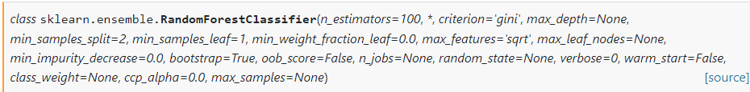

Let's apply our algorithm then:

```python
scores = []
for _ in range(25):
  rfc = RandomForestClassifier()
  rfc.fit(x_train_scaled, y_train)
  y_pred = rfc.predict(x_test_scaled)
  scores.append(rfc.score(x_test_scaled, y_test))
print(max(scores))
print(np.mean(scores))
print(min(scores))
```

```
0.8421052631578947
0.826315789473684
0.8133971291866029
```

We can make a cross validation : it is a way to train several times the algorithm on different parts of the dataset in order to reduce the risk of overfitting.

```python
rfc = RandomForestClassifier()
scores = cross_val_score(rfc, x_train_scaled, y_train, cv=10)
rfc.fit(x_train_scaled, y_train)

print("Cross-validation scores:", scores)
print("Mean cross-validation score:", scores.mean())
```

```
Cross-validation scores: [0.81437126 0.81437126 0.83832335 0.85628743 0.77844311 0.82035928
 0.81437126 0.86227545 0.85628743 0.78915663]
Mean cross-validation score: 0.8244246446865304
```

We can see our random tree classifier seems to do well. We will try to use it later on on ourselves to see if the algorithm is working with some new data !

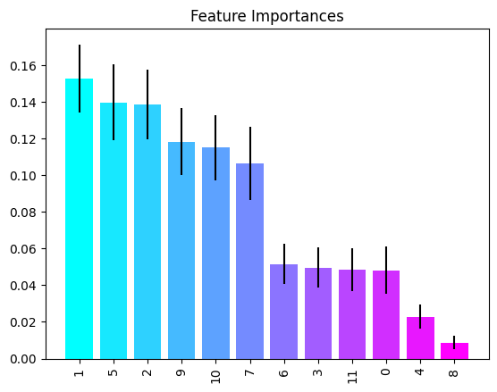

```python
features = np.concatenate((x_train_scaled, x_test_scaled), axis=0)
importances = rfc.feature_importances_
std = np.std([tree.feature_importances_ for tree in rfc.estimators_], axis=0)
indices = np.argsort(importances)[::-1]

cmap = plt.get_cmap('cool')
colors = cmap(np.linspace(0, 1, len(indices)))

plt.figure()
plt.title("Feature Importances")
plt.bar(range(features.shape[1]), importances[indices],
       color=colors, yerr=std[indices], align="center")
plt.xticks(range(features.shape[1]), pd.DataFrame(features).columns[indices], rotation='vertical')
plt.xlim([-1, features.shape[1]])
plt.show()
```

```python
x_train.columns
```

```
Index(['Gender', 'Age', 'Height', 'Family_history_with_overweight',
       'Frequency_eat_high_caloric_food', 'Frequency_eat_vegetables',
       'Frequency_eat_between_meals', 'Frequency_water',
       'Monitoring_calories_consumption', 'Frequency_physical_activity',
       'Time_using_technology_devices', 'Frequency_alcohol'],
      dtype='object')
```

This graph allows us to see which variable is the most impactful to predict the obesity type. 6 columns seem quite effective:

1. Age
2. Frequency_eat_vegetables
3. Height
4. Frequency_physical_activity
5. Time_using_technology_devices
6. Frequency_water

```python
importances_sorted = np.sort(importances)[::-1]
data_importances = {
    'Feature': [df.columns[i] for i in indices],
    'Importance': [round(importances_sorted[i]*100, 2) for i in range(len(indices))]
}
importance_df = pd.DataFrame(data_importances['Importance'], index=data_importances['Feature'])
importance_df.columns = ['% of importance']
importance_df
```

[output not shown]

```python
rfc = RandomForestClassifier()
rfc.fit(x_train_scaled, y_train)
y_pred = rfc.predict(x_test_scaled)
print(rfc.score(x_test_scaled, y_test))

y_test_np = np.array(y_test)

# Print the results
print("Predicted Labels:")
print(y_pred)

print("\nTrue Labels:")
print(y_test_np)
```

```
0.8277511961722488
Predicted Labels:
[0 3 5 2 2 2 5 3 3 1 2 4 4 5 2 1 1 1 0 2 2 2 2 2 2 1 4 3 3 4 1 5 3 5 0 3 2
 3 0 1 0 2 0 3 2 5 4 2 2 0 0 3 2 2 3 2 2 5 1 3 1 0 0 2 0 5 2 3 2 2 4 2 4 3
 5 1 5 5 1 4 0 4 2 2 0 5 3 3 5 2 4 4 2 3 2 0 4 1 4 2 2 3 1 4 2 4 5 4 1 2 1
 3 4 3 2 0 1 4 5 5 4 3 4 3 5 3 0 1 2 3 4 0 0 4 5 4 4 0 5 0 0 3 1 2 2 2 0 2
 2 4 4 4 2 3 4 1 1 1 0 3 4 5 5 5 5 2 4 2 3 5 3 2 0 2 4 2 1 1 1 1 5 2 1 2 4
 2 1 2 2 3 5 0 4 5 0 1 3 4 3 4 4 5 1 1 5 0 2 5 3 4 2 2 4 3 0 2 4 0 2 4 3 2
 2 4 3 1 3 3 1 2 4 4 0 0 2 4 4 2 5 2 4 0 4 1 5 0 1 1 5 0 2 5 3 3 2 2 1 2 4
 2 0 0 1 2 5 0 2 0 1 1 2 1 4 0 2 4 1 2 4 3 1 2 0 1 2 2 2 2 4 3 4 0 2 2 2 2
 1 2 2 5 4 1 3 5 5 2 3 5 4 4 3 1 3 4 1 3 4 4 3 3 0 3 2 2 5 2 5 3 1 0 4 2 2
 1 2 1 3 2 3 5 5 1 3 5 3 2 4 3 1 5 4 2 0 4 3 3 4 0 1 3 3 3 3 5 5 0 2 4 4 4
 2 4 2 4 1 3 4 5 3 3 2 4 1 3 2 1 3 2 1 4 5 1 1 3 4 3 3 5 3 0 4 5 4 1 1 1 5
 2 1 0 2 0 2 0 0 4 5 1]

True Labels:
[0 3 5 2 2 2 5 3 3 1 2 4 4 2 2 1 0 2 0 2 2 2 2 2 2 2 4 3 3 4 2 5 3 5 0 2 3
 3 0 1 0 2 0 3 2 5 4 2 2 0 0 3 2 2 3 4 0 5 0 3 1 0 0 3 0 5 2 3 2 2 4 2 4 3
 5 1 5 5 1 4 0 4 2 1 0 5 3 3 4 2 4 3 2 1 2 0 4 1 4 2 2 3 1 4 2 4 5 4 1 2 1
 4 4 3 2 0 2 4 5 5 4 3 4 3 5 3 0 1 2 3 4 0 0 4 5 4 4 0 5 1 0 3 3 1 2 2 0 2
 2 4 4 4 2 3 4 1 1 3 0 3 4 5 5 5 5 3 4 1 3 5 3 2 0 2 5 0 1 1 2 1 5 2 2 2 4
 2 2 2 2 3 5 0 4 5 0 1 3 2 3 4 4 5 1 1 5 0 2 5 3 4 2 2 4 3 1 1 4 0 2 2 3 2
 2 0 2 2 3 3 4 2 4 4 0 0 1 4 4 1 5 2 4 0 4 1 5 0 2 2 5 1 2 5 3 3 2 2 0 1 4
 2 0 0 1 2 5 0 2 0 1 0 2 3 4 1 2 4 1 1 4 3 1 2 0 2 4 2 2 3 4 3 4 0 2 2 2 2
 1 2 2 5 4 1 3 5 5 2 3 5 4 3 3 2 3 4 2 3 4 2 3 3 0 3 1 2 5 1 5 3 1 0 4 2 3
 1 2 2 3 2 3 5 5 1 3 5 3 2 2 3 1 5 2 2 0 5 3 3 4 0 1 2 3 3 3 5 5 0 2 2 2 4
 2 4 2 4 1 3 3 5 3 1 2 4 1 3 2 1 3 2 1 4 5 1 1 4 4 3 3 5 2 0 4 5 4 1 1 1 5
 2 2 0 2 1 1 0 0 2 5 1]
```

Let's have a look on the confusion matrix:

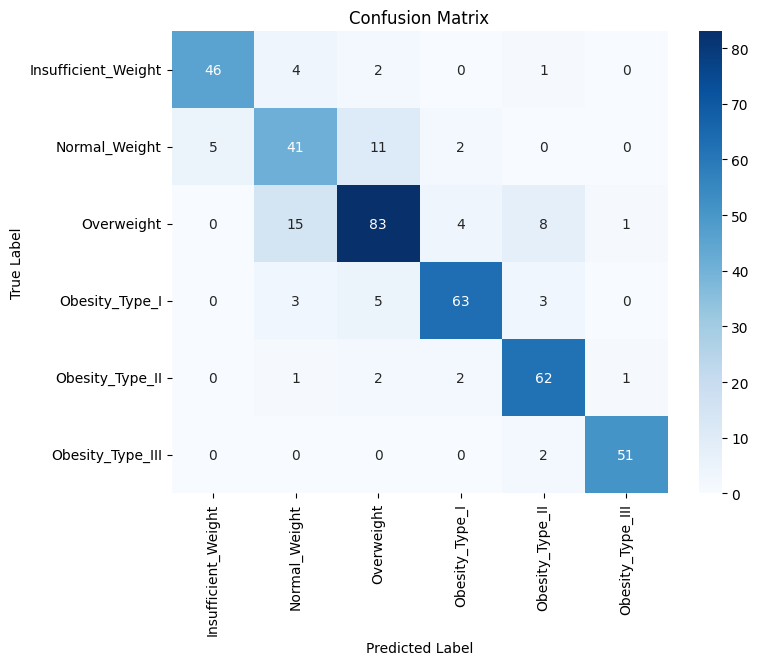

```python
cm = confusion_matrix(y_test_np, y_pred)

plt.figure(figsize=(8, 6))
sns.heatmap(cm, annot=True, fmt='d', cmap='Blues', xticklabels=decoded_dict['Corrected_obesity_level_category'].values(), yticklabels=decoded_dict['Corrected_obesity_level_category'].values())
plt.title('Confusion Matrix')
plt.xlabel('Predicted Label')
plt.ylabel('True Label')

plt.show()
```

Another default parameter we didn't consider here is Bootstrap = True. Bootstrapping resamples the original dataset with replacement many thousands of times to create simulated datasets. This process involves drawing random samples from the original dataset. Hence it is better to avoid overfitting, as every tree will be different.

```python
average_df = df.drop(columns = ['Corrected_obesity_level_category', 'MBI', 'Obesity_level_category', 'Weight','Number_of_main_meals', 'Main_transport_Bike', 'Main_transport_Automobile', 'Main_transport_Motorbike','Main_transport_Public_Transportation','Main_transport_Walking', 'Smoke'])

average_people = {col:[] for col in average_df}
for col in average_df.columns:
  average_people[col].append(round(np.mean(df[df['Gender']==1][col])))
  average_people[col].append(round(np.mean(df[df['Gender']==0][col])))

average_people_df = pd.DataFrame(average_people)
average_people_df_scaled = scaler.transform(average_people_df)
average_people_prediction = rfc.predict(average_people_df_scaled)

genders = ['Average man', 'Average woman']
results = [decoded_dict['Corrected_obesity_level_category'][result] for result in average_people_prediction]
matrix_results = np.array([genders,results])
matrix_results
```

```
array([['Average man', 'Average woman'],
       ['Normal_Weight', 'Obesity_Type_III']], dtype='<U16')
```

Therefore, exclusively from the data contained in this dataset, we can deduce that out of the people interrogated, the average man in all of the categories except MBI, Weight, and Obesity type, probably belongs in the Normal Weight type of obesity, whereas the average woman is predicted to belong in the Obesity_Type_III category (sometimes in the Obesity_Type_III but that depends on the random factor each time we run our model).

This analysis very clearly shows the mispresentation we showed earlier as categorizing the average woman in the Obseity_Type_III (the highest one) is completely unrealistic and unrepresentative of the global population. This is majorly explained by the fact that out of the 264 people categorized in that obesity type, 263 of them are women, which gives WAY too much importance to that feature, much more than it should up to this point.

Just out of curiosity, we will test the acccuracy of our algorithm on us, the members of this project :

```python
for col in decoded_dict:
  print(f"{col} : {decoded_dict[col]}")
```

```
Gender : {0: 'Female', 1: 'Male'}
Family_history_with_overweight : {1: 'yes', 0: 'no'}
Frequency_eat_high_caloric_food : {0: 'no', 1: 'yes'}
Frequency_eat_between_meals : {2: 'Sometimes', 1: 'Frequently', 0: 'Always', 3: 'no'}
Smoke : {0: 'no', 1: 'yes'}
Monitoring_calories_consumption : {0: 'no', 1: 'yes'}
Frequency_alcohol : {3: 'no', 2: 'Sometimes', 1: 'Frequently', 0: 'Always'}
Obesity_level_category : {1: 'Normal_Weight', 5: 'Overweight_Level_I', 6: 'Overweight_Level_II', 2: 'Obesity_Type_I', 0: 'Insufficient_Weight', 3: 'Obesity_Type_II', 4: 'Obesity_Type_III'}
Age : Numeric values
Height : Numeric values
Weight : Numeric values
MBI : Numeric values
Frequency_eat_vegetables : {1: 'Never', 2: 'Sometimes', 3: 'Always'}
Number_of_main_meals : {1: '1/day', 2: '2/day', 3: '3/day', 4: '3+/day'}
Frequency_water : {1: 'Less than 1L/day', 2: 'Between 1 and 2L/day', 3: 'More than 2L/day'}
Frequency_physical_activity : {0: 'No activity', 1: '1 or 2 days/week', 2: '2 or 4 days/week', 3: '4+ days/week'}
Time_using_technology_devices : {0: '0-2 hours/day', 1: '3-5 hours/day', 2: '5+ hours/day'}
Main_transport_Automobile : {0: 'no', 1: 'yes'}
Main_transport_Bike : {0: 'no', 1: 'yes'}
Main_transport_Motorbike : {0: 'no', 1: 'yes'}
Main_transport_Public_Transportation : {0: 'no', 1: 'yes'}
Main_transport_Walking : {0: 'no', 1: 'yes'}
Corrected_obesity_level_category : {0: 'Insufficient_Weight', 1: 'Normal_Weight', 2: 'Overweight', 3: 'Obesity_Type_I', 4: 'Obesity_Type_II', 5: 'Obesity_Type_III'}
```

This is simply to help us know which value we should assign to ourselves.

```python
"""group_members = {'Gender': [1,1], 'Age': [21,20], 'Height': [1.80,1.76], 'Family_history_with_overweight': [1,0], 'Frequency_eat_high_caloric_food': [1,1], 'Frequency_eat_vegetables': [2,2],
                 'Number_of_main_meals': [2,3], 'Frequency_eat_between_meals': [1,1], 'Smoke': [0,0], 'Frequency_water': [2,2], 'Monitoring_calories_consumption': [0,0],
                 'Frequency_physical_activity': [2,1], 'Time_using_technology_devices': [2,2], 'Frequency_alcohol': [3,2], 'Main_transport_Automobile': [0,0], 'Main_transport_Bike' :[0,0],
                 'Main_transport_Motorbike':[0,0], 'Main_transport_Public_Transportation': [1,1],'Main_transport_Walking' : [0,0]}"""

group_members = {'Gender': [1,1,1], 'Age': [21,20,21], 'Height': [1.80,1.76,1.74], 'Family_history_with_overweight': [1,0,0],
                 'Frequency_eat_high_caloric_food': [1,1,1], 'Frequency_eat_vegetables': [2,2,2], 'Frequency_eat_between_meals': [1,1,2],
                 'Frequency_water': [2,2,2], 'Monitoring_calories_consumption': [0,0,1], 'Frequency_physical_activity': [2,1,1],
                 'Time_using_technology_devices': [2,2,2], 'Frequency_alcohol': [3,2,2]}

group_members_df = pd.DataFrame(group_members)
group_members_df_scaled = scaler.transform(group_members_df)
group_members_prediction = rfc.predict(group_members_df_scaled)

members = ['Louis', 'Killian', 'Marc']
predicted_results = [decoded_dict['Corrected_obesity_level_category'][result] for result in group_members_prediction]
matrix_predicted_results = np.array([members,predicted_results])
print(matrix_predicted_results)
```

```
[['Louis' 'Killian' 'Marc']
 ['Normal_Weight' 'Normal_Weight' 'Overweight']]
```

```python
members_weight = [67.0, 59.0, 65.0]
real_MBI = [members_weight[i]/group_members['Height'][i]**2 for i in range(len(members))]
real_results = [decoded_dict['Corrected_obesity_level_category'][GetCategory(mbi)] for mbi in real_MBI]

matrix_real_results = np.array([members,real_MBI,real_results])
print(matrix_real_results)
```

```
[['Louis' 'Killian' 'Marc']
 ['20.679012345679013' '19.047004132231404' '21.469150482230148']
 ['Normal_Weight' 'Normal_Weight' 'Normal_Weight']]
```